# Kiire ja lihtne daignostiline test COVID-19 tuvastamiseks mis põhineb isotermilisel amplifikatsioonil (LAMP).

# Sissejuhatus

**Viimastel aastatel on isotermiline amplifikatsioon - LAMP tänu oma kiirusele, täpsusele ning spetsiifilusele võimeline asendama standardset PCR. Viimane aga on laialt levinud meetod, mis kasutab kaht praimerit DNA/RNA paljundamiseks ning termostaati. LAMP meetod kasutab 4-6 praimeri paari spetsiifilise regiooni amplifitseerimiseks ning konstantset temperatuuri vahemikus 63-65C. Antud artiklis kirjeldatakse isotermilise amplifikatsiooni baasil töötava meetodi (RT-LAMP) mille abil saab kiiresti tuvastada SARS-CoV-2. SARS-CoV-2 on kõrge patogeensusega koronaviirus, mis on põhjustanud kogu maailmas puhangu. RT-LAMP-SARS-CoV-2 ei anna ristreaktsiooni ka kõige lähedasema inimese koronaviirusega, SARS-CoV. Kliiniline uuring SARS-CoV-2 (COVID-19) kahtlusega patsientidega (ninast võetud proovid) näitas, et RT-LAMP meetod suutis 15 minuti jooksul tuvastada 100% tõenäosusega üle 23,7 viraalset koopiat. Samuti saab RT-LAMP meetodit teha kaasaskantava akut toetava seadmega, mis teeb seda veelgi mugavaks kus viimast saab kergesti ka kodus kasutada. Töös oli kirjeldatud ka otsene RT-LAMP (puudub RNA puhastamise etapp), mis suutis tuvastada 15 minuti jooksul 100% tõenäosusega rohkem kui 1,43 x 10<sup>3</sup> SARS-CoV-2 koopiat, seega saab seda kasutada esimeseks skreenimiseks halvasti varustatud piirkondades nagu arenevad riigid.**

Esmakordselt teatati detsembris 2019, et Wuhanist, Hiinas oli tuvastatud koronaviiruse (SARS-CoV-2) puhang ning juba 11. märtsil 2020 kuulutas Maailma Terviseorganisatsioon (WHO) koroonaviiruse haiguse (COVID-19) pandeemiaks. COVID -19 iseloomustab tavaliselt palavik, köha, väsimus ning progresseeeruva hingamispuudulikuse või mitmete organite puudulikkuse tõttu ka 3.4 % suremus. Haiguse inkubatsiooni aeg on tavaliselt vahemikus 5-19 päeva, mis raskendab veegi nakkuse leviku ärahoidmist. Kuna peamine nakatamine toimub aerosooltilkade kaudu on isolatsioon kõige tõhusam viis viiruse ärahoidmiseks. Seega on SARS-CoV-2 kiire ning sensitiivne diagnostiline test esmatähtis, et mitte ainult alustada sobiva ravimiga infektsiooni algstaadiumil vaid ka takistada viiruse ulatuslikku levikut. SARS-CoV-2 diagnoositakse laboris peamiselt nukleiinhapete amplifikatsiooni testide abil (NAAT). Kohe peale SARS-CoV-2 genoomjärjestuse sekveneerimisele töötasid välja teadlased testi, mis sobiks viiruse tuvastamiseks (RT-qPCR) ja mis on hetkel ka kuldstandard SARS-CoV-2 viirusspetsiifilise RNA tuvastamiseks. Antud test nõuab RNA puhastamist ning ka stabiilse elektriga ühendatud termostaati. Samas alati on potentsiaalne risk, viraalse RNA degradeerimiseks transpordi käigus ning ka termostaat on üsna kallis. Kõik see aga raskendab testi läbiviimist sellistes kohtades nagu arenevad riigid samas uus innovatiivne test, mis oleks mõeldud kodukasutuseks ning oleks sensitiivne saaks lahendada need probleemid. Antud artiklis kirjeldatakse RT-LAMP meetodit, mis oma lihtne, kiire ning mille tundlikkus on võrreldav standardse RT-qPCR iga. Lisaks saab antud testi saaks kasutada otseselt, ilma RNA puhastamise etapita, mis teeks seda testi veelgi kiireks.

## Tulemused

#### **RT-LAMPi detektsiooni aeg**

RT-LAMP jaoks olid disainitud 2 praimeri komplekti konserveerunud ORF1b regiooni tuvastamiseks (ORF1b-1 ja ORF1b-2). Selleks et määrata mitu koopiat suudab iga praimeri paar tuvastada tehti 10X RNA lahjendusi. Kasutades praimereid ORF1b-1 ning ORF1b-2 regiooni tuvastamiseks ja vähemalt 50 RNA koopiat oli sensitiivsuseks vastavate praimerite jaoks 100% (6/6) ja 83% (5/6). Pealegi suutsid nii RT-LAMP / ORF1b-1 kui ka RT-LAMP / ORF1b-2 tuvastada 100% sensitiivsusega 500 RNA koopiat vähem kui 8 minuti jooksul (7.3 ja 7.4 vastavalt) ja 50 RNA koopiat vähemalt 11 minuti jooksul (9.4 ja 10.4) **(joonis1)**. Need tulemused näitavad, et RT-LAMPi võib kasutada SARS-CoV-2 kiireks ja täpseks tuvastamiseks.

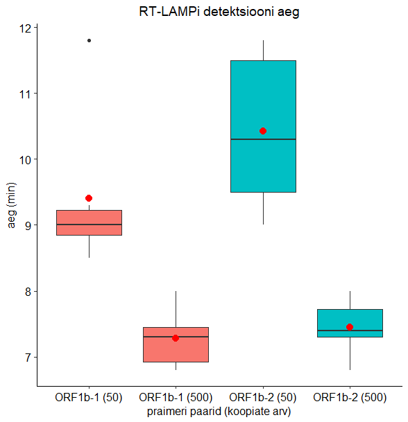

Joonis1. RT-LAMP meetodi detektsiooni aeg

#### **RT-LAMP testi spetsiifilisus**

Testi spetsiifilisuse uurimiseks teosati testi kõige lähedasema SARS-CoV -2 tüvega. Mõlemad praimerid ei andnud amplifikatsiooni antud tüvega ja ainult SARS-CoV-2 RNA oli amplifitseeritav vastavate parimeri paaridega.

#### **RT-LAMP testi ja RT-qPCR testi kiirus ning sensitiivsus**

Tundlikkuse määramiseks võrreldi RT-LAMP/ORF1b-1 ja RT-LAMP/ORF1b-2 kuldstandarditega (RT-qPCR/NIID; RT-qPCR/WHO) ning kasutati 10X RNA lahjendus, kus RNA oli ektraheeritud SARS-CoV-2 JPN/TY/WK-521 tüvest (GISAID: EPI-ISL-408667). Mõlema praimeri paariga ORF1b regiooni tuvastamisel oli RT-LAMPi keskmine detektsiooni aeg 10<sup>-2</sup> RNA lahjenduse puhul 6.5 minutit; 10<sup>-3</sup> RNA lahjenduse puhul 7.6 minutit ja 10<sup>-4</sup> RNA lahjenduse puhul 10.3 minutit **(joonis2)**. Mõlemad praimerid näitasid 100% sensitiivsust. RT-qPCRi kasutamisel pikenes aga detektsiooni aeg, nii oli mõlema NIID ja WHO praimeritega see vastavalt 10<sup>-2</sup> lahjendusel 31 ja 29 minutit; 10<sup>-3</sup> lahjendusel 34 ja 33 minutit ja 10<sup>-4</sup> lahjendusel 38 ja 36 minutit. Ka siin näitasid mõlemad kuldstandardid 100% sensitiivsust.

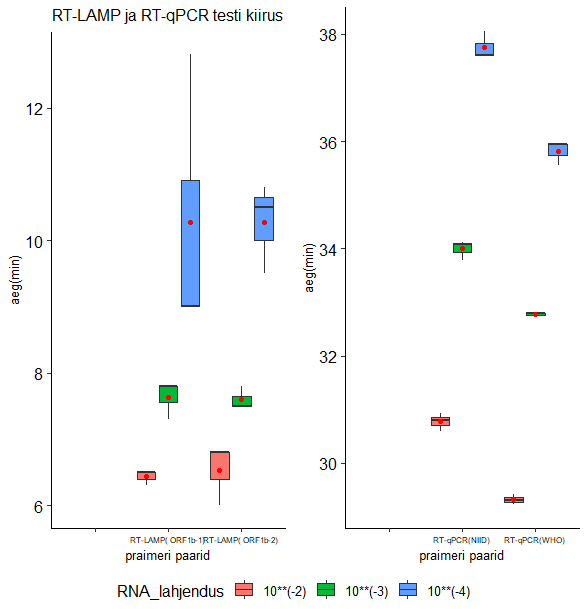

Joonis2. RT-LAMP testi ja RT-qPCR testi kiirus

#### **Otsene RT-LAMP**

Tavaliselt nõuavad genoomsed analüüsimeetodid RNA puhastamise etapi, protsess on aeganõudev ja võtab vähemalt 30 minutit. Antud artiklis rakendati RT-LAMP puhastamata proovidele, kasutades ninast ja kurgust võetud materjali, millele oli lisatud SARS-CoV-2 JPN/TY/WK-521 tüvi. Analüüsiks kautati 10x lahjendusi (materjal võetud ninast/kurgust) ning võrdlemiseks ka RT-LAMP/ORF1b-1 (kus RNA oli puhastatud eelnevatest proovidest , kuhu sai lisatud SARS-CoV-2). **Joonis 3** näitab, et detektsiooni aeg on otsese RT-LAMP puhul pikem võrreldes RT-LAMP iga. Kui RT-LAMP suutis 4.8 minutiga tuvastada 10<sup>-2</sup> lahjendust ning 7.9 minutiga 10<sup>-6</sup> lahjendust siis otsene RT-LAMP oli natuke aeglasem ning vastav aeg oli 5.4 ja 9.5 minutit. Samas mõlemad meetodid suutsid 33% tõenaosusega amplifitseerida ka 10<sup>-7</sup> lahjendust. Näeme ka et ka otsene RT-qPCR/NIID on aeglasem võrreldes RT-qPCR/NIID iga (10<sup>-2</sup> lahjenduse puhul on aeg 23 ja 21 minutit ning 10<sup>-6</sup> lahjenduse puhul on aeg vastavalt 37 ja 34.5 minutit). RT-qPCR tuvastas aga 100% se sensitiivsusega 10<sup>-7</sup> RNA lahjendusi. See aga näitab et nina/kurgu materjali otsene kasutamine reaktsioonis aeglustab amplifikatsiooni. Samas tulemused näitavad, et otsene RT-LAMPi saab kasutada SARS-CoV-2 diagnoosimiseks.

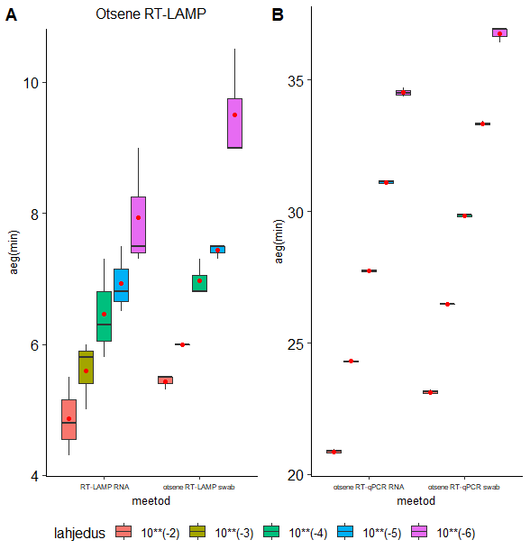

Joonis3. Otsese LAMP testi kiirus

#### **RT-LAMP testi hindamine kasutades kliinilisi proove**

Selleks et hinata RT-LAMPi (ekstraheeriti RNAd) ning otsest RT-LAMPi diagnostilist sensitiivsust analüüsiti nende meetodiga COVID-19 kahtlusega 208 patsiente (algselt oli 224, kuid kuna üks puhver aeglustas amplifikatsiooni, siis jäti need patsiendid uuringust välja kelle proovid võeti ülesse HBSS lahuses), kellel sai võetud ninast materjal amplifitseerimiseks (referentsiks oli RT-qPCR/NIID). Kokku 208 patsiendist 126 oli RT-qPCR iga COVID-19 positiivsed (antud testides kesmine RNA sisaldus varieerus 1.3 kuni 6.88x10<sup>7</sup>koopiat reaktsiooni kohta). RT-LAMP / ORF1b-1 test andis 100% positiivse amplifikatsiooni kõikidega kliiniliste proovidega mis sisaldasid rohkem kui 23.7 viraalset RNAd. 50 % tõenäosusega oli test võimeline tuvastama 10-19.8 koopiat. Positiivne tulemus saadi kui reaktsiooni aeg oli vähemalt 14.5 minutit. Tabelist näha et RT-LAMP testi üldine sensitiivsus on 94.4% ning spetsiifilisus 82%. Otsene RT-LAMP ORF1b-1 praimeritega sai 100% tõenäosusega tuvastada viirust proovidest, kus oli rohkem kui 1.43x10<sup>3</sup>koopiat, ning 53% ja 10% tõenäosuga vastavalt 10<sup>2</sup>-10<sup>3</sup> ning 10<sup>1</sup>-10<sup>2</sup> koopiat. Ning minimaalselt oli test võimeline tuvastama 70.8 koopiat. Tabelist näha et RT-LAMP testi üldine sensitiivsus on 63%. Seega peab silmas pidama, et madal viraalne sisaldus võib anda valenegatiivset tulemust, kui kasutada otsest RT-LAMP.

|  | RT-LAMP: Positiivsed | RT-LAMP: Negatiivsed | otsene RT-LAMP: Positiivsed | otsene RT-LAMP : Negatiivsed |
| --- | --- | --- | --- | --- |
| RT-qPCR: Positiivsed | 119 | 7 | 80 | 46 |
| RT-qPCR: Negatiivsed | 15 | 67 | NA | NA |

# Kokkuvõtte

Antud artiklis töötati välja kiire, sensitivse meetod SARS-CoV-2 infektsiooni tuvastamiseks, mis põhines isotermilisel amplifikatsioonil (RT-LAMP). Antud assay on võimeline 15 minuti jooksul tuvastama 23.7 koopiat viraalse RNAd kliinilistest proovidest. Hetkel kasutatakse RT-qPCRi kuldstandardina, samas antud protseduur on ajakulukas e võtab 2-3 tundi. Töös sai näidatud ka otsene RT-LAMP, mis ei vaja eelnevalt RNA puhastamist proovist. Viimane suudab tuvastada 203 viraalset koopiat lahusest 10.5 minuti jooksul ning ka seda saaks potentsiaalselt kasutada esimeseks screenimiseks.

# Kasutatud kirjandus

https://pubmed.ncbi.nlm.nih.gov/33147214/